# Clustering basado en densidades

Los algoritmos de agrupación en clústeres basados en la densidad asignan la pertenencia al clúster en función de la proximidad a otros miembros del clúster. Persiguen el objetivo de identificar regiones densas de formas y tamaños arbitrarios. No requieren la especificación de un cierto número de conglomerados, sino que se basan en parámetros que definen el tamaño de un vecindario y un umbral de densidad.

## Dependencias y configuración

```python
import warnings
warnings.filterwarnings('ignore')
```

```python
%matplotlib inline

from time import sleep
from random import shuffle

import numpy as np
from numpy import atleast_2d
import pandas as pd

from sklearn.decomposition import PCA
from sklearn.cluster import DBSCAN, KMeans
from sklearn.metrics import adjusted_mutual_info_score
from sklearn.preprocessing import StandardScaler
from sklearn.datasets import load_iris


import matplotlib.pyplot as plt
from matplotlib.colors import ListedColormap
from matplotlib import cm
import matplotlib.ticker as ticker
import seaborn as sns

from IPython import display
```

```python
cmap = cm.get_cmap('viridis')
cmap = ListedColormap(sns.xkcd_palette(['denim blue',
                                        'medium green',
                                        'pale red']))
```

## Ejemplo para entender DBSCAN con los datos Iris

```python
iris = load_iris()
iris.keys()
```

```
dict_keys(['data', 'target', 'frame', 'target_names', 'DESCR', 'feature_names', 'filename'])
```

## Crear un data frame

```python
features = iris.feature_names
data = pd.DataFrame(data=np.column_stack([iris.data,
                                          iris.target]),
                    columns=features + ['label'])
data.label = data.label.astype(int)
data.info()
```

```
<class 'pandas.core.frame.DataFrame'>
RangeIndex: 150 entries, 0 to 149
Data columns (total 5 columns):
 #   Column             Non-Null Count  Dtype
---  ------             --------------  -----
 0   sepal length (cm)  150 non-null    float64
 1   sepal width (cm)   150 non-null    float64
 2   petal length (cm)  150 non-null    float64
 3   petal width (cm)   150 non-null    float64
 4   label              150 non-null    int32
dtypes: float64(4), int32(1)
memory usage: 5.4 KB
```

### Estandarizar los datos

```python
scaler = StandardScaler()
features_standardized = scaler.fit_transform(data[features])
n = len(data)
```

### Reducir la dimensión para visualizar los grupos

```python
pca = PCA(n_components=2)
features_2D = pca.fit_transform(features_standardized)
```

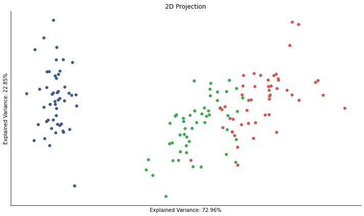

```python
ev1, ev2 = pca.explained_variance_ratio_
ax = plt.figure(figsize=(10, 6)).gca(title='2D Projection',
                      xlabel=f'Explained Variance: {ev1:.2%}',
                      ylabel=f'Explained Variance: {ev2:.2%}')
ax.scatter(*features_2D.T, c=data.label, s=25, cmap=cmap)
ax.set_xticklabels([])
ax.set_xticks([])
ax.set_yticklabels([])
ax.set_yticks([])
sns.despine()
plt.tight_layout();
```

## Perform DBSCAN clustering

Density-based spatial clustering of applications with noise (DBSCAN) se desarrolló en 1996.

Su objetivo es identificar muestras centrales y no centrales, donde las primeras extienden un clúster y las segundas son parte de un clúster pero no tienen suficientes vecinos cercanos para hacer crecer aún más el clúster. Otras muestras son valores atípicos y no se asignan a ningún grupo.

Utiliza un parámetro eps para el radio de la vecindad y min_samples para el número de miembros necesarios para las muestras del núcleo. Es determinista y exclusivo y tiene dificultades con grupos de diferente densidad y datos de alta dimensión.

https://scikit-learn.org/stable/modules/generated/sklearn.metrics.adjusted_mutual_info_score.html

```
 1    71
 0    45
-1    34
Name: clusters, dtype: int64
```

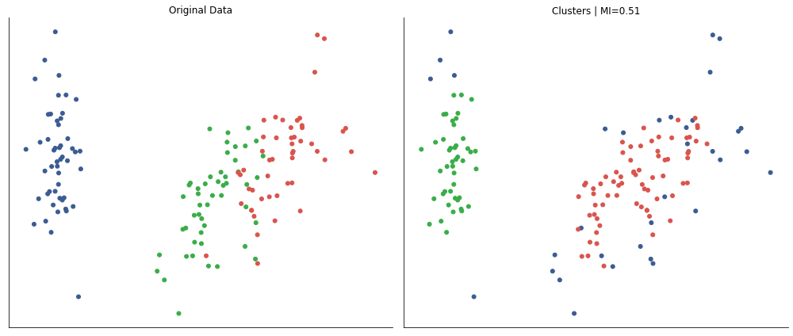

```python
clusterer = DBSCAN() # los parámetros del algoritmo por defecto son:
# DBSCAN(
#     eps=0.5,
#     *,
#     min_samples=5,
#     metric='euclidean',
#     metric_params=None,
#     algorithm='auto',
#     leaf_size=30,
#     p=None,
#     n_jobs=None,
# )

data['clusters'] = clusterer.fit_predict(features_standardized)
print(data['clusters'].value_counts())
fig, axes = plt.subplots(ncols=2,
                         figsize=(14, 6))

labels, clusters = data.label, data.clusters
mi = adjusted_mutual_info_score(labels, clusters)# mide lo que se parecen las dos columnas
# labels son los tipos de flor y clusters los obtenidos por el método DBSCAN

axes[0].scatter(*features_2D.T, c=data.label, s=25, cmap=cmap)
axes[0].set_title('Original Data')
axes[1].scatter(*features_2D.T, c=data.clusters, s=25, cmap=cmap)
# axes[1].set_title('Clustering data')
axes[1].set_title('Clusters | MI={:.2f}'.format(mi))

for ax in axes:
    ax.axes.get_xaxis().set_visible(False)
    ax.axes.get_yaxis().set_visible(False)
sns.despine()
fig.tight_layout()
```

```python
# https://scikit-learn.org/stable/modules/generated/sklearn.metrics.adjusted_mutual_info_score.html
adjusted_mutual_info_score(labels, labels)
```

```
1.0
```

### Comparación de parámetros de configuración

```python
eps_range = np.arange(.2, .91, .05)
min_samples_range = list(range(3, 10))
labels = data.label
mi = {}
for eps in eps_range:
    for min_samples in min_samples_range:
        clusterer = DBSCAN(eps=eps, min_samples=min_samples)
        clusters = clusterer.fit_predict(features_standardized)
        mi[(eps, min_samples)] = adjusted_mutual_info_score(clusters, labels)
```

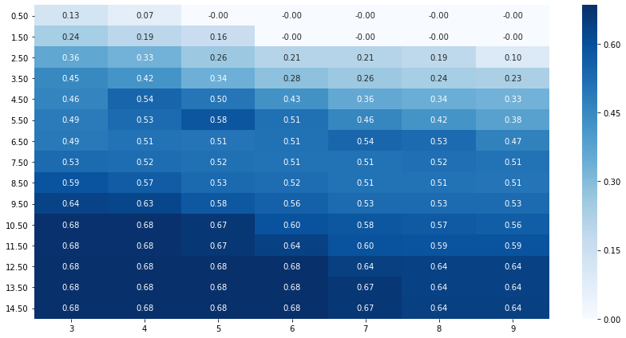

```python
results = pd.Series(mi)
results.index = pd.MultiIndex.from_tuples(results.index)
fig, axes = plt.subplots(figsize=(12, 6))
ax = sns.heatmap(results.unstack(),
                 annot=True,
                 fmt='.2f',
                 cmap='Blues')
ax.yaxis.set_major_formatter(ticker.FormatStrFormatter('%0.2f'))
plt.tight_layout()
```

### Correr otra vez

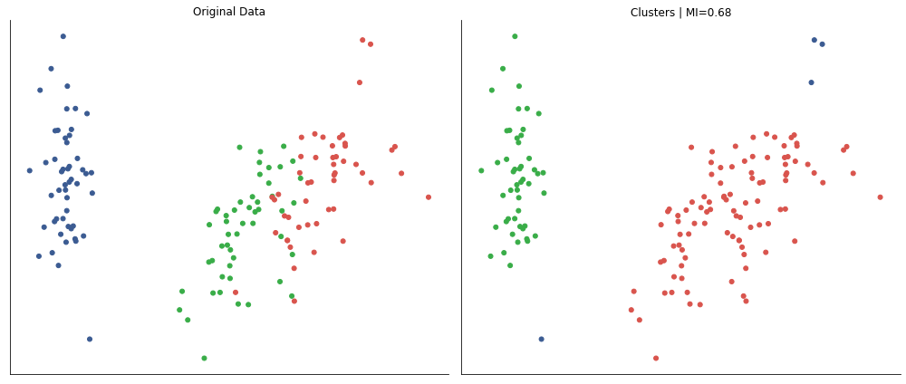

```python
clusterer = DBSCAN(eps=.8, min_samples=5)
data['clusters'] = clusterer.fit_predict(features_standardized)

labels, clusters = data.label, data.clusters
mi = adjusted_mutual_info_score(labels, clusters)

fig, axes = plt.subplots(ncols=2, figsize=(14, 6))
axes[0].scatter(*features_2D.T, c=data.label, s=25, cmap=cmap)
axes[0].set_title('Original Data')
axes[1].scatter(*features_2D.T, c=data.clusters, s=25, cmap=cmap)
axes[1].set_title('Clusters | MI={:.2f}'.format(mi))

for ax in axes:
    ax.axes.get_xaxis().set_visible(False)
    ax.axes.get_yaxis().set_visible(False)
sns.despine()
plt.tight_layout()
```

### Kmeans

```python
Sum_of_squared_distances = []

for k in range(1,20):
    km = KMeans(n_clusters=k)
    km = km.fit(features_standardized)
    Sum_of_squared_distances.append(km.inertia_)
```

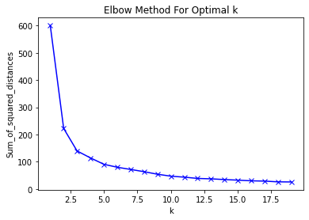

```python
plt.plot(range(1,20), Sum_of_squared_distances, 'bx-')
plt.xlabel('k')
plt.ylabel('Sum_of_squared_distances')
plt.title('Elbow Method For Optimal k')
plt.show()
```

```
1    53
0    50
2    47
Name: clusters_km, dtype: int64
```

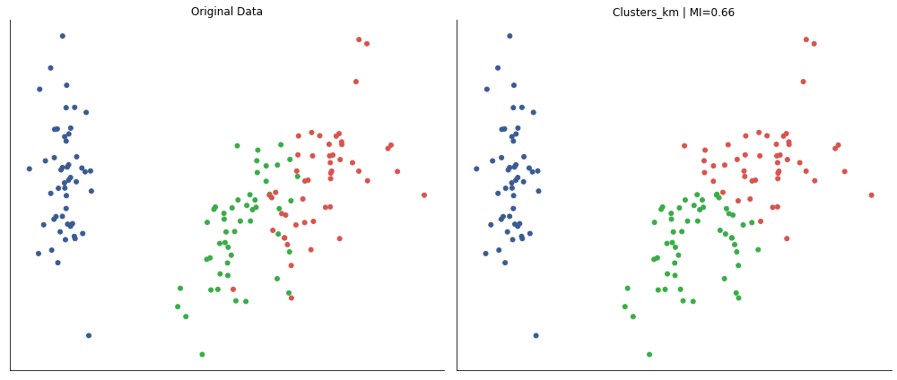

```python
clusterer_km = KMeans(n_clusters=3)
data['clusters_km'] = clusterer_km.fit_predict(features_standardized)
print(data['clusters_km'].value_counts())
fig, axes = plt.subplots(ncols=2,
                         figsize=(14, 6))

labels, clusters_km = data.label, data.clusters_km
mi = adjusted_mutual_info_score(labels, clusters_km)# mide lo que se parecen las dos columnas
# labels son los tipos de flor y clusters los obtenidos por el método DBSCAN

axes[0].scatter(*features_2D.T, c=data.label, s=25, cmap=cmap)
axes[0].set_title('Original Data')
axes[1].scatter(*features_2D.T, c=data.clusters_km, s=25, cmap=cmap)
# axes[1].set_title('Clustering data')
axes[1].set_title('Clusters_km | MI={:.2f}'.format(mi))

for ax in axes:
    ax.axes.get_xaxis().set_visible(False)
    ax.axes.get_yaxis().set_visible(False)
sns.despine()
fig.tight_layout()
```